# Zhang Jinhao - Bayerische Staatsoper

[figure not shown]

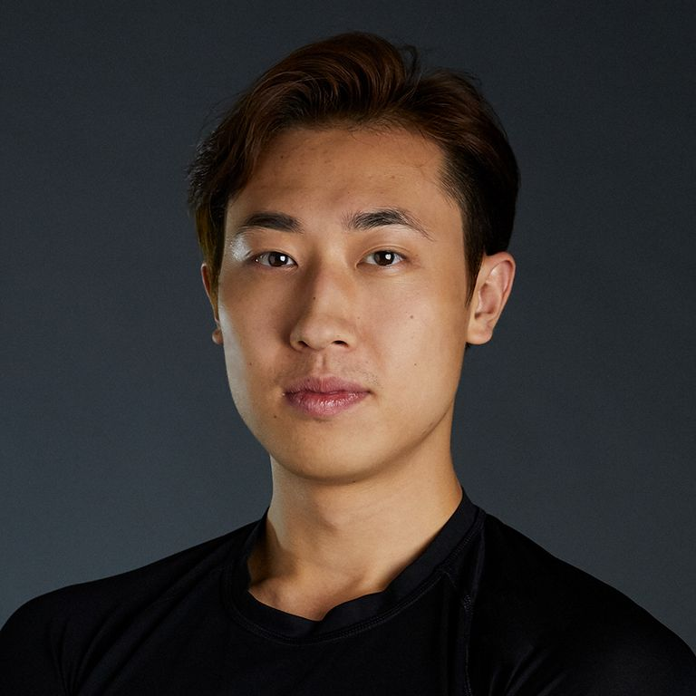

# Jinhao Zhang

**Erster Solist**  
Jinhao Zhang wurde 1995 in Dalian, China geboren und wuchs in Shanghai auf. Von 2010 bis 2014 studierte er an der Tongji-Universität Shanghai. 2013 wurde er von der English National Ballet School aufgenommen, 2014 an das English National Ballet engagiert. Ab der Spielzeit 2017/18 war Jinhao Zhang als Demi-Solist beim Bayerischen Staatsballett engagiert. Er wurde mit Beginn der Spielzeit 2018/19 zum Solisten und zur Spielzeit 2021/22 zum Ersten Solisten befördert.  
Stand Juli 2021  
**Auszeichnungen**  
Silbermedaille bei der Genée International Ballet Competition, 2011  
Gewinner beim Prix de Lausanne, 2013  
Gewinner des Emerging Dancer Award, 2015  
Silbermedaille und Auszeichnung für die beste Choreographie bei der Beijing International Ballet and Choreography Competition, 2015  
**Repertoire**  
Ali und Lankedem in *Le Corsaire* (M. Petipa)  
Le Sacre du Printemps (P. Bausch)  
Paris in *Romeo und Julia* (R. Nurejew)  
Der Nussknacker in *Der Nussknacker* (W. Eagling)  
*Giselle* (P. Wright/M. Petipa)  
**Debüts beim Bayerischen Staatsballett**  
Pas de six in *Der Widerspenstigen Zähmung* (J. Cranko)  
Crassus in *Spartacus* (Y. Grigorovich)  
Faschingsprinz in *Romeo und Julia* (J. Cranko)  
Kostja in *Anna Karenina* (C. Spuck)  
Tänzer in *Borderlands - Portrait Wayne McGregor* (W. McGregor)  
Graf Jean de Brienne in *Raymonda* (R. Barra, M. Petipa)  
Richard in *Cecil Hotel* (A. Kaydanovskiy)  
Solo-Paar in *Jewels (Diamonds)* (G. Balanchine)  
Wronski in *Anna Karenina* (C. Spuck)  
Des Grieux in *Die Kameliendame* (J.Neumeier)  
Prinz Siegfried in *Schwanensee* (Ray Barra)  
Albrecht in *Giselle* (J. Coralli/J. Perrot/M. Petipa)  
Burmin in *Der Schneesturm* (A. Kaydanovskiy)  
Tänzer in *Broken Fall* (R. Maliphant)  
Tänzer in *With a Chance of Rain* (L. Scarlett)  
Prinz Guillaume in *Cinderella* (C.Wheeldon)  
Tänzer in *Bilder einer Ausstellung* (A. Ratmansky)  
Theseus/Oberon in *Ein Sommernachtstraum* (J. Neumeier)  
Romeo in *Romeo und Julia* (J. Cranko)  
Tänzer in *Elegie -* Tschaikowski-Ouvertüren(A. Ratmansky)  
Tänzer in *Der Sturm -* Tschaikowski-Ouvertüren (A. Ratmansky)

Fr 13.01.23

## EIN SOMMERNACHTSTRAUM

John Neumeier  
19.30 Uhr, Nationaltheater  
Abo-Serie 50 Ballett

Ballett

Mi 18.01.23

## EIN SOMMERNACHTSTRAUM

John Neumeier  
19.30 Uhr, Nationaltheater  
Abo-Serie 12

Ballett

So 22.01.23

## PASSAGEN

David Dawson, Marco Goecke, Alexei Ratmansky  
18.00 Uhr, Nationaltheater  
Abo-Serie 26

Ballett

Do 26.01.23

## PASSAGEN

David Dawson, Marco Goecke, Alexei Ratmansky  
19.30 Uhr, Nationaltheater  
Abo-Opern-Geschenk-Abo 170, <30

Ballett

Sa 31.12.22

## DIE FLEDERMAUS

Johann Strauß  
18.00 Uhr, Nationaltheater

Preise O

Oper